# Assignment MP1

Sonam Rathod

2024-10-17

#### 1. Create Timeseries

```r
library(forecast)
```

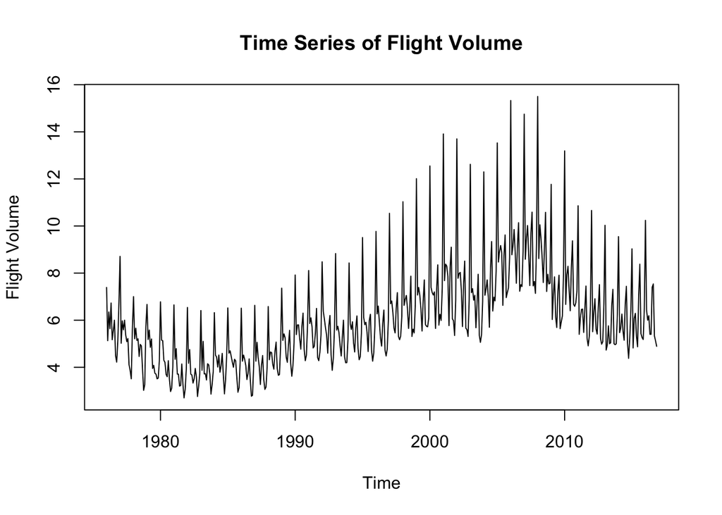

```r
flightVolume <- read.csv("~/Downloads/flightVolume.csv")

reslong_ts <- ts(flightVolume$reslong, start = c(1976, 1), end = c(2016, 11), frequency = 12)
plot(reslong_ts, main="Time Series of Flight Volume", ylab="Flight Volume", xlab="Time")
```

There is trend and seasonality both in the dataset.

From 1990-2005, there is an upward trend in data, meaning increase in flight volume. After 2005, trend is bit stable and started decreasing trend around 2010. along with that,there is a clear and consistent seasonal pattern in the data.

#### 2. Verify how much history to include in your analysis.

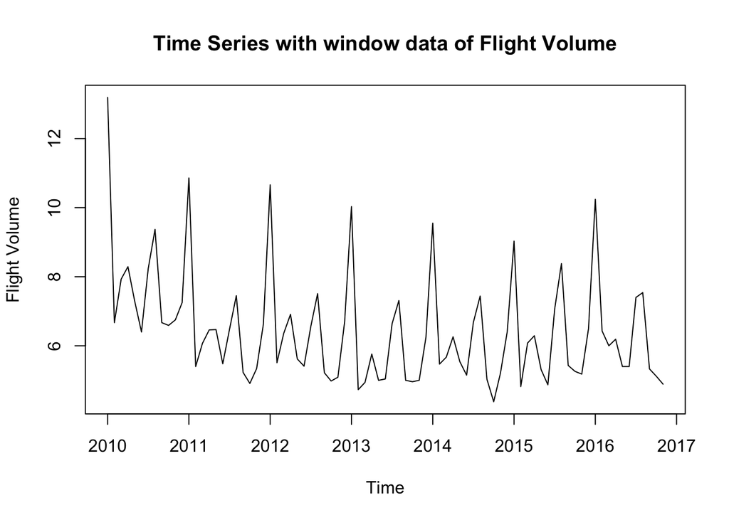

```r
reslong_window_ts <- window(reslong_ts, start= c(2010,1), end = c(2016, 11), frequency = 12)
plot(reslong_window_ts, main="Time Series with window data of Flight Volume", ylab="Flight Volume", xlab="Time")
```

From 1990 to 2005, the data indicates a clear upward trend in flight volumes, followed by a decline around 2009. After 2010, the trend stabilizes and remains relatively flat. The significant recession in 2008 likely contributed to the observed dip, with some recovery evident around 2010; however, the market has not returned to its earlier peak levels.

Focusing on more recent data from 2010 onwards is beneficial for a few reasons. Firstly, recent data is more reflective of the current market dynamics and industry conditions, making it more relevant for forecasting and decision-making. Including older historical data, which spans different economic cycles and industry changes, may introduce noise and reduce the accuracy of the analysis due to its less relevance to present trends. By concentrating on recent data, we can develop models that better capture the current state of the market, leading to more precise and actionable insights.

#### 3. Hypothesize if the dataset has trend, seasonality, or both.

The dataset has both seasonality and trend.

#### 4. Verify using Acf

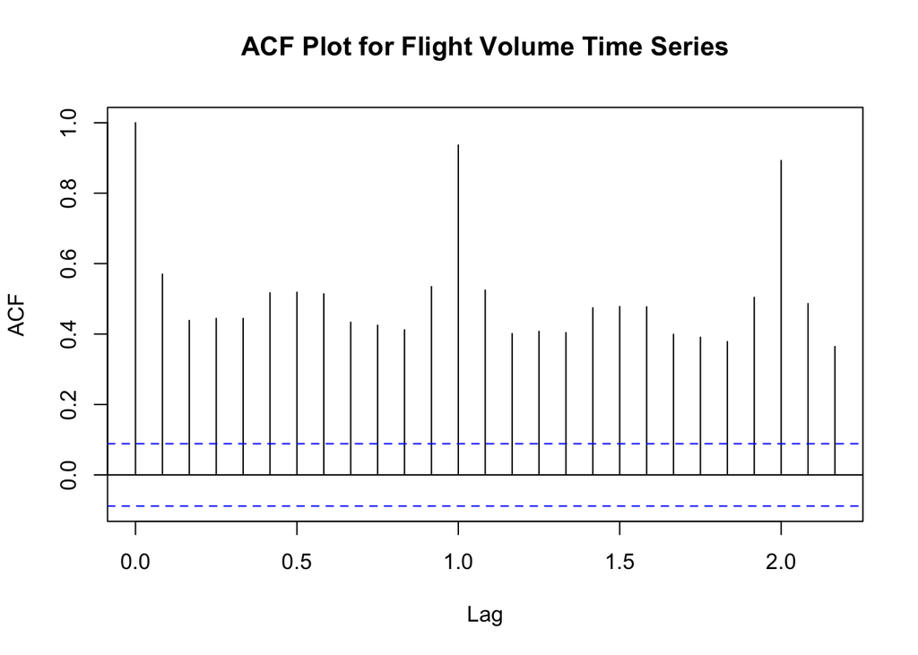

```r
acf(reslong_ts, main="ACF Plot for Flight Volume Time Series")
```

1. Seasonality: The significant spikes at regular intervals in the ACF plot indicate a strong seasonal pattern in the data.
2. Trend: The presence of slowly decaying correlations in the ACF plot also indicates a trend in the data.

Given these observations, our hypothesis that the dataset has both trend and seasonality appears to be correct.

#### 5. Verify using decomposition

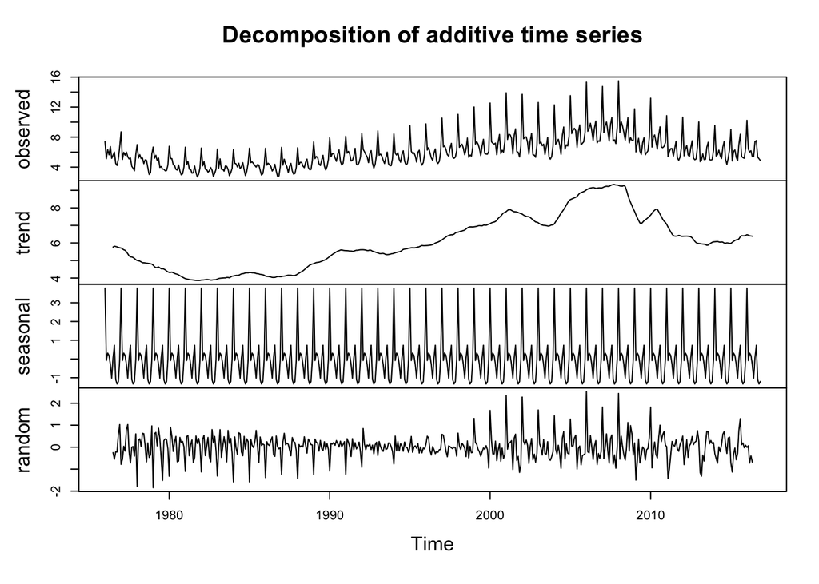

```r
decomposed_reslong <- decompose(reslong_ts)
plot(decomposed_reslong)
```

From 1990 to 2005, flight volumes showed a strong upward trend, followed by a decline around 2010 that eventually leveled off. There is a clear seasonal pattern that repeats every year.

Based on decomposition:

- Trend: The data shows an overall increasing trend over time, although the trend appears to decrease in recent years.
- Seasonality: The strong repeating pattern in the seasonal component confirms the seasonality.

Hence, our hypothesis is correct, the data has both seasonality and trend.

#### 6. Chose an accuracy measure

Going with common accuracy measures:

- Mean Absolute Error (MAE)
- Root Mean Squared Error (RMSE)
- Mean Absolute Percentage Error (MAPE)

#### 7. Create a forecast model for the next 12 months. Include Naive, Average, Exponential Smoothing, HoltWinters, and Decomposition (both types).

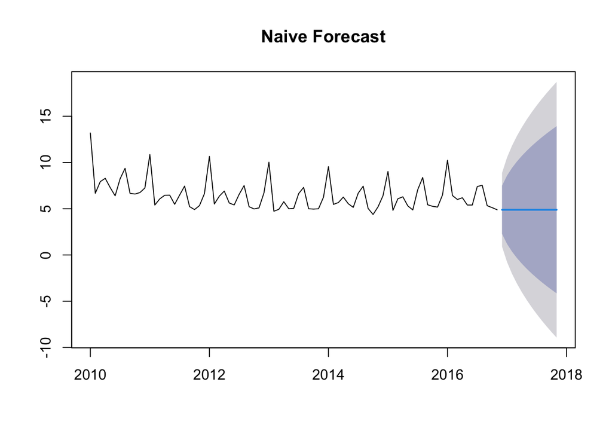

```r
naive_forecast <- naive(reslong_window_ts, h=12)
plot(naive_forecast, main="Naive Forecast")
```

**Naive Model**: The simplest model, forecasting that future values will be the same as the last observed value. The forecasted line is constant and flat for the next 12 months.

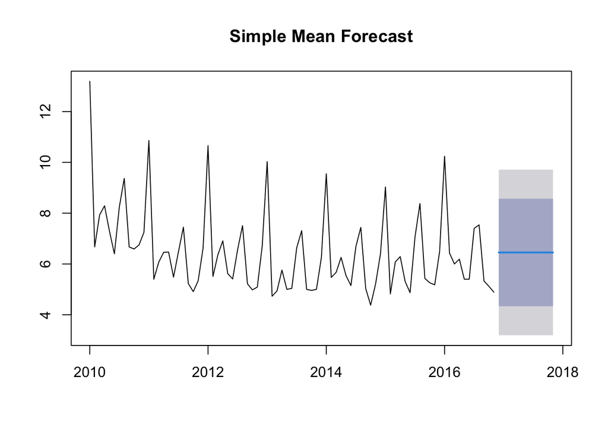

```r
simple_forecast <- meanf(reslong_window_ts, h=12)
plot(simple_forecast, main="Simple Mean Forecast")
```

**Simple Average Model**: This forecasts using the mean of all historical observations. It shows the flat line for future even if there is a trend or seasonality.

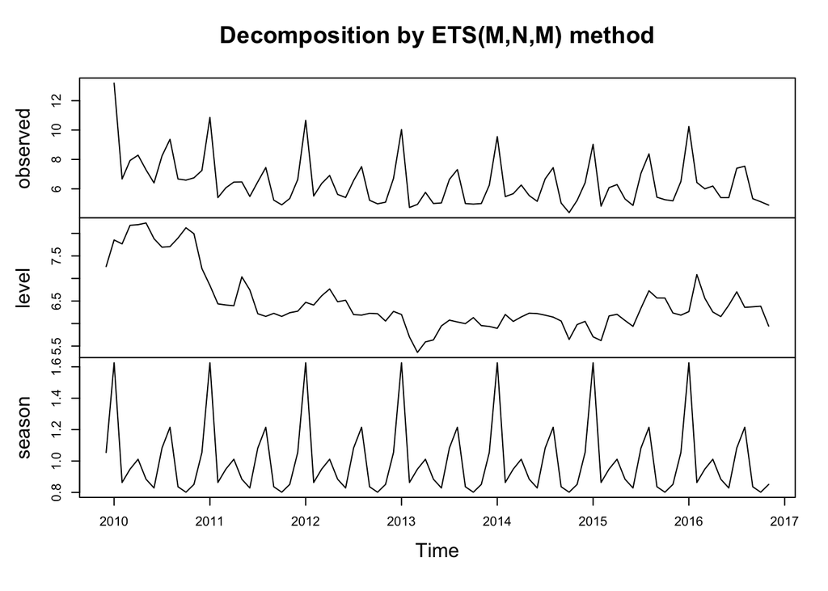

```r
ets_forecasting <- ets(reslong_window_ts)
plot(ets_forecasting)
```

```r
summary(ets_forecasting)
```

```
## ETS(M,N,M)
##
## Call:
## ets(y = reslong_window_ts)
##
##   Smoothing parameters:
##     alpha = 0.6933
##     gamma = 1e-04
##
##   Initial states:
##     l = 7.2647
##     s = 1.0543 0.8508 0.8012 0.8359 1.2148 1.0828
##            0.8282 0.8839 1.0111 0.9483 0.8631 1.6255
##
##   sigma:  0.0667
##
##      AIC     AICc      BIC
## 237.7898 244.9540 274.0724
##
## Training set error measures:
##                       ME      RMSE       MAE        MPE    MAPE      MASE
## Training set -0.02137417 0.4136749 0.2945089 -0.5895448 4.51627 0.5120012
##                    ACF1
## Training set 0.09249627
```

**Smoothing Parameters:**

- Alpha = 0.6933: A high alpha means the model is highly responsive to recent changes in the data.
- Gamma = 1e-04: The gamma value is low, meaning that the seasonal component is hardly being updated with new data, so the model is depended on historical seasonality patterns.

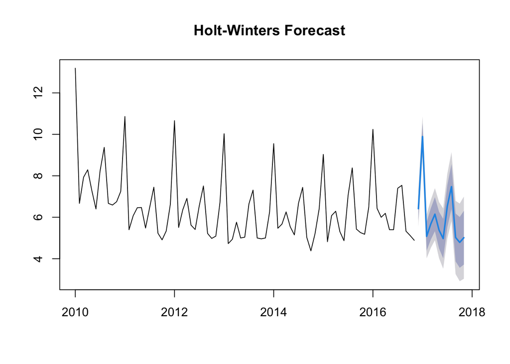

```r
hw_forecast <- hw(reslong_window_ts, h=12)
plot(hw_forecast, main="Holt-Winters Forecast")
```

**Holt-Winters model** is forecasting both trend and seasonal effects for the next 12 months.

```r
summary(hw_forecast)
```

```
##
## Forecast method: Holt-Winters' additive method
##
## Model Information:
## Holt-Winters' additive method
##
## Call:
## hw(y = reslong_window_ts, h = 12)
##
##   Smoothing parameters:
##     alpha = 0.4541
##     beta  = 0.0266
##     gamma = 1e-04
##
##   Initial states:
##     l = 8.5713
##     b = -0.1052
##     s = 0.3167 -0.9556 -1.1938 -0.9686 1.4719 0.522
##            -1.0565 -0.6592 0.0976 -0.3877 -0.9948 3.808
##
##   sigma:  0.4427
##
##      AIC     AICc      BIC
## 247.7355 257.1509 288.8558
##
## Error measures:
##                     ME      RMSE       MAE       MPE     MAPE      MASE
## Training set 0.0424706 0.3977796 0.2999711 0.4734295 4.709079 0.5214973
##                    ACF1
## Training set 0.01061561
##
## Forecasts:
##          Point Forecast    Lo 80     Hi 80    Lo 95     Hi 95
## Dec 2016       6.414125 5.846737  6.981513 5.546380  7.281870
## Jan 2017       9.893844 9.264321 10.523367 8.931072 10.856616
## Feb 2017       5.079384 4.387201  5.771568 4.020781  6.137987
## Mar 2017       5.674977 4.919438  6.430515 4.519479  6.830474
## Apr 2017       6.148722 5.329016  6.968427 4.895090  7.402354
## May 2017       5.380342 4.495577  6.265106 4.027211  6.733472
## Jun 2017       4.971445 4.020674  5.922215 3.517366  6.425523
## Jul 2017       6.538456 5.520693  7.556219 4.981921  8.094991
## Aug 2017       7.476685 6.390916  8.562454 5.816145  9.137226
## Sep 2017       5.024694 3.869888  6.179499 3.258571  6.790816
## Oct 2017       4.787877 3.562993  6.012762 2.914579  6.661176
## Nov 2017       5.014533 3.718522  6.310544 3.032455  6.996611
```

- alpha = 0.4541 This controls the smoothing of the level. A value of 0.4541, the model gives reasonable weight to both recent observations and past data when updating the level.
- beta = 0.0266 The trend is changing very slowly over time
- gamma = 1e-04 The model assumes that the seasonal pattern is fairly consistent over time and doesn’t change much.

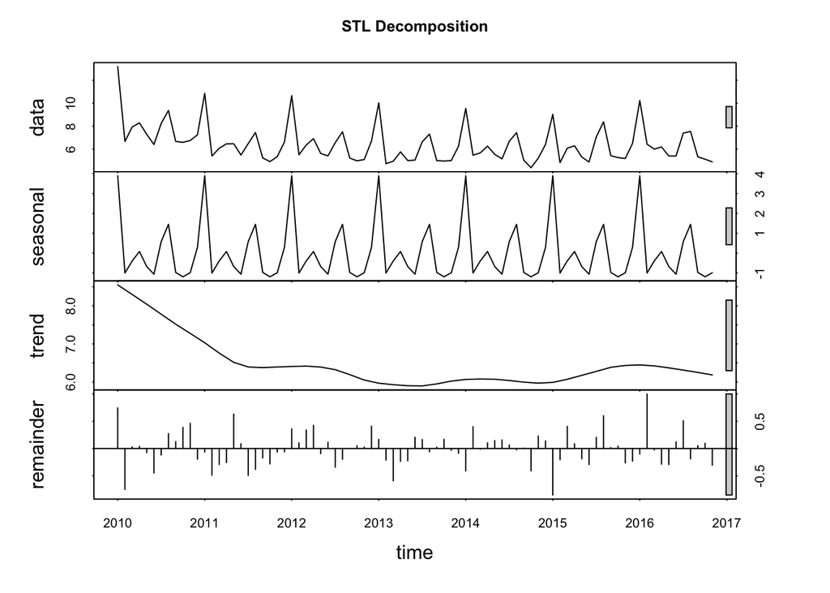

```r
res_stl <- stl(reslong_window_ts, s.window = "periodic")
plot(res_stl, main = "STL Decomposition")
```

```r
summary(res_stl)
```

```
##  Call:
##  stl(x = reslong_window_ts, s.window = "periodic")
##
##  Time.series components:
##     seasonal             trend            remainder
##  Min.   :-1.193216   Min.   :5.895608   Min.   :-0.8522370
##  1st Qu.:-0.996782   1st Qu.:6.046971   1st Qu.:-0.2183567
##  Median :-0.676784   Median :6.322782   Median : 0.0006450
##  Mean   :-0.003519   Mean   :6.462746   Mean   :-0.0066976
##  3rd Qu.: 0.435515   3rd Qu.:6.433625   3rd Qu.: 0.1518685
##  Max.   : 3.894265   Max.   :8.549274   Max.   : 0.9999801
##  IQR:
##      STL.seasonal STL.trend STL.remainder data
##      1.4323       0.3867    0.3702        1.7400
##    %  82.3         22.2      21.3         100.0
##
##  Weights: all == 1
##
##  Other components: List of 5
##  $ win  : Named num [1:3] 831 19 13
##  $ deg  : Named int [1:3] 0 1 1
##  $ jump : Named num [1:3] 84 2 2
##  $ inner: int 2
##  $ outer: int 0
```

- Seasonality: The seasonal component is about 82.3% of the variation in the data, showing that seasonality is quite strong.
- Trend: The trend is about 22.2% of the variation, which confirms a trend over time.
- Residuals: The remainder component explains 21.3% of the total variation, showing that the random component is relatively small.

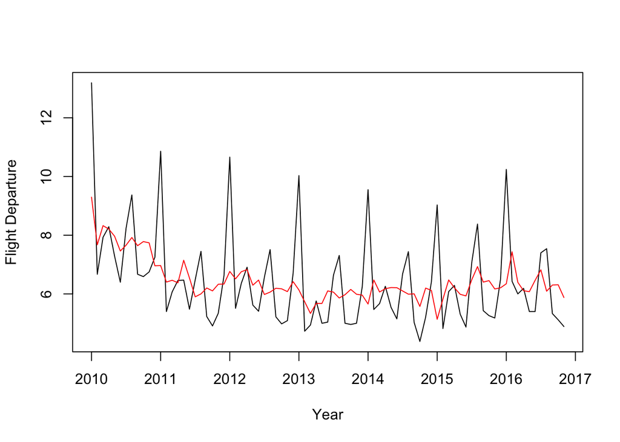

```r
plot(reslong_window_ts,ylab = "Flight Departure", xlab = "Year")

lines(seasadj(res_stl), col="Red")
```

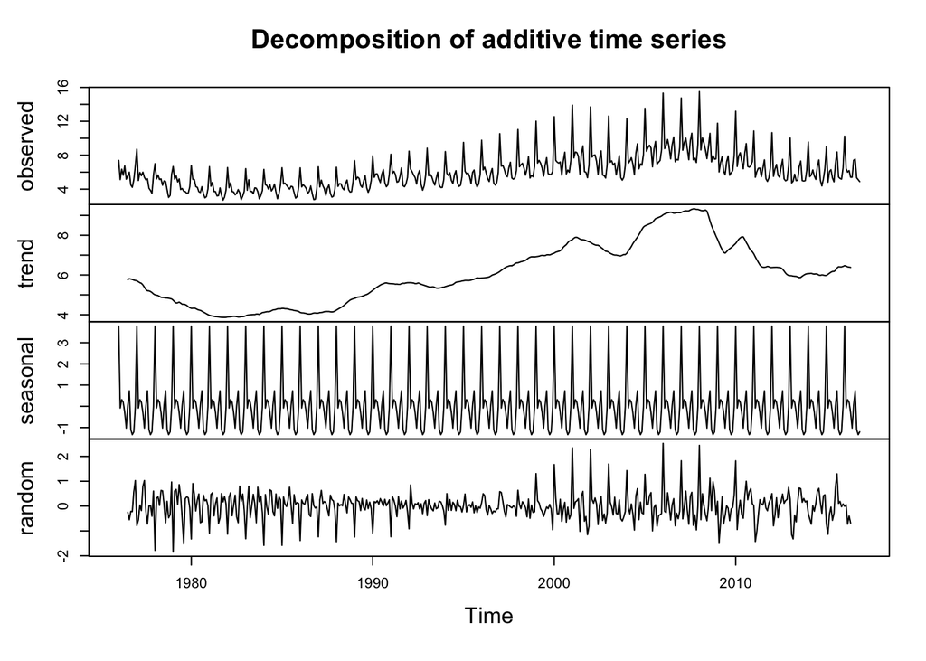

```r
decomposed_additive <- decompose(reslong_window_ts, type = "additive")
plot(decomposed_reslong)
```

**Additive Decomposition**: The seasonal and trend components are added together, with constant seasonal variations over time.

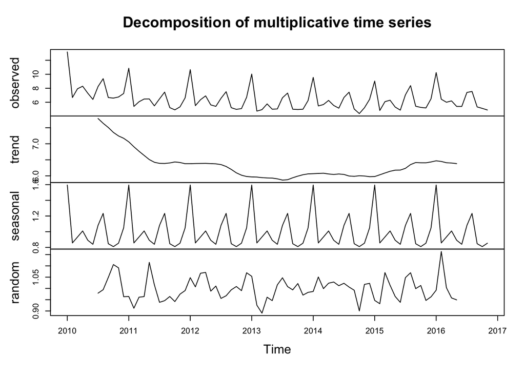

```r
decomposed_multiplicative <- decompose(reslong_window_ts, type = "multiplicative")
plot(decomposed_multiplicative)
```

**Multiplicative Decomposition**: The seasonal and trend components are multiplied, with seasonal variations proportional to the trend.

#### 8. Show model rank with accuracy measures

```r
accuracy_naive <- accuracy(naive_forecast)
accuracy_avg <- accuracy(simple_forecast)
accuracy_ets <- accuracy(ets_forecasting)
accuracy_hw <- accuracy(hw_forecast)

# Create a comparison table
accuracy_table <- data.frame(
  Model = c("Naive", "Average", "ETS", "Holt-Winters"),
  MAE = c(accuracy_naive["Training set", "MAE"], accuracy_avg["Training set", "MAE"], accuracy_ets["Training set", "MAE"],accuracy_hw["Training set", "MAE"]),
  RMSE = c(accuracy_naive["Training set", "RMSE"], accuracy_avg["Training set", "RMSE"], accuracy_ets["Training set", "RMSE"], accuracy_hw["Training set", "RMSE"]),
  MAPE = c(accuracy_naive["Training set", "MAPE"], accuracy_avg["Training set", "MAPE"], accuracy_ets["Training set", "MAPE"], accuracy_hw["Training set", "MAPE"])
)

accuracy_table$Rank_MAE <- rank(accuracy_table$MAE)
accuracy_table$Rank_RMSE <- rank(accuracy_table$RMSE)
accuracy_table$Rank_MAPE <- rank(accuracy_table$MAPE)

print(accuracy_table)
```

```
##          Model       MAE      RMSE      MAPE Rank_MAE Rank_RMSE Rank_MAPE
## 1        Naive 1.4239024 2.0365376 22.413596        4         4         4
## 2      Average 1.1783481 1.6194271 17.800230        3         3         3
## 3          ETS 0.2945089 0.4136749  4.516270        1         2         1
## 4 Holt-Winters 0.2999711 0.3977796  4.709079        2         1         2
```

#### 9. Choose which models and how are you going to use them for Forecasting

Based on the accuracy rank, ETS or Holt-Winters Model is more accurate for forecasting.

#### 10. Provide the forecast for the next 12 months (point and range) and explain why you feel confident with these forecasts

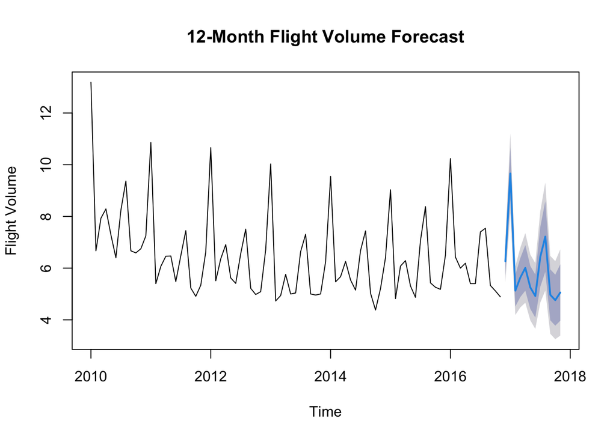

```r
forecast_12_months <- forecast(ets_forecasting, h = 12)
plot(forecast_12_months, main = "12-Month Flight Volume Forecast", ylab = "Flight Volume", xlab = "Time")
```

The blue line represents the forecast for the next 12 months. This is the model is best estimate of future flight volume, based on the data.

```r
print(forecast_12_months)
```

```
##          Point Forecast    Lo 80     Hi 80    Lo 95     Hi 95
## Dec 2016       6.265385 5.729650  6.801121 5.446049  7.084722
## Jan 2017       9.660306 8.654463 10.666149 8.122002 11.198611
## Feb 2017       5.129246 4.514195  5.744296 4.188607  6.069885
## Mar 2017       5.635829 4.881313  6.390344 4.481897  6.789761
## Apr 2017       6.008783 5.128217  6.889349 4.662073  7.355493
## May 2017       5.253167 4.421971  6.084362 3.981963  6.524371
## Jun 2017       4.921789 4.089386  5.754192 3.648739  6.194839
## Jul 2017       6.434779 5.280477  7.589081 4.669426  8.200132
## Aug 2017       7.219443 5.854188  8.584699 5.131465  9.307422
## Sep 2017       4.967476 3.982054  5.952898 3.460403  6.474548
## Oct 2017       4.761420 3.774636  5.748205 3.252263  6.270577
## Nov 2017       5.056203 3.965224  6.147182 3.387695  6.724711
```

```r
summary(ets_forecasting)
```

```
## ETS(M,N,M)
##
## Call:
## ets(y = reslong_window_ts)
##
##   Smoothing parameters:
##     alpha = 0.6933
##     gamma = 1e-04
##
##   Initial states:
##     l = 7.2647
##     s = 1.0543 0.8508 0.8012 0.8359 1.2148 1.0828
##            0.8282 0.8839 1.0111 0.9483 0.8631 1.6255
##
##   sigma:  0.0667
##
##      AIC     AICc      BIC
## 237.7898 244.9540 274.0724
##
## Training set error measures:
##                       ME      RMSE       MAE        MPE    MAPE      MASE
## Training set -0.02137417 0.4136749 0.2945089 -0.5895448 4.51627 0.5120012
##                    ACF1
## Training set 0.09249627
```

```r
ets_forecasting$par['alpha']
```

```
##     alpha
## 0.6932744
```

```r
ets_forecasting$par['gamma']
```

```
##        gamma
## 0.0001000597
```